# Assignment 3: Pathway and Network Analysis

BCB420 - Computational Systems Biology

Vivian Wang

April 4, 2023

# Introduction and preparation

In Assignment 1, we began processing the GEO dataset GSE157852: this is a bulk RNA-seq dataset from the paper, “Human Pluripotent Stem Cell-Derived Neural Cells and Brain Organoids Reveal SARS-CoV-2 Neurotropism Predominates in Choroid Plexus Epithelium” by Jacob et al. (2020). The transcriptome analysis in this paper studies the effects of SARS-CoV-2 infection on gene expression in choroid plexus organoids (CPOs). CPOs underwent 2 treatments (either mock control or SARS-CoV-2 exposure). The mock group was analyzed at 72 hours post-infection (hpi), while the virus-exposed group was analyzed at 2 timepoints, 24 and 72 hpi. There are thus 3 groups (Mock_72hpi, SARS-CoV-2_24hpi, and SARS-CoV-2_72hpi) of 3 samples each, making the total sample size 9. The dataset contains raw gene counts of 29,755 genes, represented by HUGO gene symbols. After filtering out weakly expressed and non-informative features, the dataset includes 12,929 genes.

We then normalized the data via Trimmed Mean of M-values (TMM) normalization, which assumes that most genes are not differentially expressed, and that there are a similar number of up- and down- regulated genes in the data across samples. The boxplots, density distributions, and multidimensional scaling (MDS) plots showed noticeable, but not drastic, improvement in similarity between samples, and clustering of samples within the same group. Finally, we saved the normalized gene counts as a CSV file.

In Assignment 2, we used the normalized gene counts to conduct differential gene expression and thresholded over-representation analysis (ORA). We designed a model based on the 3 predefined groups, then, using the edgeR package, calculated differential gene expression between each pair of groups. As expected, the comparison between mock control and SARS-CoV-2_72hpi resulted in the highest number of differentially expressed genes that passed our significance threshold. To continue our analysis with the results from this comparison, we saved the up- and down-regulated gene lists, as well as a ranked gene list, as txt files. We also visualized the differential expression of the top up- and down-regulated genes by producing a heatmap, showing that the mock control and SARS-CoV-2_72hpi groups had the most significant differences in gene expression, while the two virus-exposed groups were most similar.

Using g:Profiler, we performed thresholded ORA to observe the biological pathway enrichment of the up- and down-regulated gene lists both separately and combined. The up-regulated gene list yielded a greater number of significantly enriched genesets than the down-regulated list. Top enriched genesets for the up-regulated gene list, as opposed to those for the down-regulated gene list, tended to also be more enriched for the combined list. The thresholded ORA results mostly supported the enrichment analysis results from the original paper Jacob et al. (2020). Similar to the paper, our analysis found enrichment of viral/inflammatory response and cytoskeleton organization processes among the up-regulated genes, along with enrichment of homeostasis and membrane transport processes among the down-regulated genes.

Finally, in Assignment 3, we will now use the ranked gene list to conduct non-thresholded gene set enrichment analysis (GSEA), and visualize the results as a network using the Enrichment Map app from Cytoscape.

## Installing packages

```r
if (!requireNamespace("knitr", quietly = TRUE)){
  install.packages("knitr")}
```

# Non-thresholded gene set enrichment analysis

#### What method did you use? What genesets did you use? Make sure to specify versions and cite your methods.

We ran Gene Set Enrichment Analysis (GSEA) 4.3.2 through its desktop graphical interface (Subramanian et al. (2005), Mootha et al. (2003)). Since we already prepared a ranked gene list after calculating differential expression from Assignment 2, we used the “Run GSEAPreranked” tool in the interface.

For the genesets database, we downloaded the current (2 March 2023) version of the Bader Lab human geneset containing GO Biological Process, all pathways, no IEA, and using HUGO gene symbols. This file (“Human_GOBP_AllPathways_no_GO_iea_March_02_2023_symbol.gmt”) was downloaded directly from the [Bader Lab’s Enrichment Map Genesets site](http://download.baderlab.org/EM_Genesets/March_02_2023/Human/symbol/) “Enrichment Map Genesets” (2023).

We used our preranked gene list from Assignment 2, with number of permutations set to 1000 and no collapsing to gene symbols. The size of genesets to be included was set to 15 as the minimum and 200 as the maximum. All other fields were set to the default.

#### Summarize your enrichment results.

To examine the results, we located the output enrichment files and copied them to the ./Data directory.

```r
gsea_up <- read.delim("./Data/gsea_report_for_na_pos_1680236862639.tsv", sep = "\t", header = TRUE)
gsea_down <- read.delim("./Data/gsea_report_for_na_neg_1680236862639.tsv", sep = "\t", header = TRUE)
```

Our GSEA included 4974 genesets after filtering by size. 3363 of these are enriched in the up-regulated genes, with 855 genesets significantly enriched (FDR < 0.25). 1611 genesets are enriched in the down-regulated genes, with 93 significantly enriched (FDR < 0.25).

```r
# Extract the geneset name, size, enrichment score (ES), normalized ES (NE)S, and FDR q-value
top_up_genesets <- subset(gsea_up, select = c(NAME, SIZE, ES, NES, FDR.q.val))
# Show the top 15 enriched genesets
knitr::kable(top_up_genesets[1:15,], type = "html")
```

| NAME | SIZE | ES | NES | FDR.q.val |
| --- | --- | --- | --- | --- |
| CYTOSKELETAL REGULATION BY RHO GTPASE%PANTHER PATHWAY%P00016 | 44 | 0.8544174 | 2.178698 | 0.0000000 |
| HALLMARK_TNFA_SIGNALING_VIA_NFKB%MSIGDBHALLMARK%HALLMARK_TNFA_SIGNALING_VIA_NFKB | 120 | 0.7276804 | 2.153521 | 0.0000000 |
| HALLMARK_EPITHELIAL_MESENCHYMAL_TRANSITION%MSIGDBHALLMARK%HALLMARK_EPITHELIAL_MESENCHYMAL_TRANSITION | 121 | 0.7066174 | 2.116683 | 0.0000000 |
| SMOOTH MUSCLE CONTRACTION%REACTOME%R-HSA-445355.6 | 30 | 0.8815737 | 2.074536 | 0.0003232 |
| INTEGRIN-MEDIATED SIGNALING PATHWAY%GOBP%GO:0007229 | 49 | 0.7984016 | 2.054496 | 0.0002586 |
| METABOLISM OF POLYAMINES%REACTOME DATABASE ID RELEASE 83%351202 | 50 | 0.7918142 | 2.052050 | 0.0002155 |
| HIV INFECTION%REACTOME%R-HSA-162906.2 | 195 | 0.6551295 | 2.042796 | 0.0001847 |
| REGULATION OF RAS BY GAPS%REACTOME DATABASE ID RELEASE 83%5658442 | 58 | 0.7422588 | 2.004608 | 0.0004847 |
| HOST INTERACTIONS OF HIV FACTORS%REACTOME DATABASE ID RELEASE 83%162909 | 111 | 0.6885905 | 2.003053 | 0.0004309 |
| GLI3 IS PROCESSED TO GLI3R BY THE PROTEASOME%REACTOME%R-HSA-5610785.1 | 55 | 0.7631417 | 1.997705 | 0.0005150 |
| DEGRADATION OF GLI1 BY THE PROTEASOME%REACTOME%R-HSA-5610780.1 | 54 | 0.7503404 | 1.997644 | 0.0004682 |
| DECTIN-1 MEDIATED NONCANONICAL NF-KB SIGNALING%REACTOME%R-HSA-5607761.1 | 54 | 0.7580768 | 1.996129 | 0.0005346 |
| HEDGEHOG LIGAND BIOGENESIS%REACTOME%R-HSA-5358346.1 | 54 | 0.7553069 | 1.994461 | 0.0004935 |
| ANTIGEN PROCESSING-CROSS PRESENTATION%REACTOME DATABASE ID RELEASE 83%1236975 | 77 | 0.7239132 | 1.992933 | 0.0004583 |
| SCF-BETA-TRCP MEDIATED DEGRADATION OF EMI1%REACTOME DATABASE ID RELEASE 83%174113 | 49 | 0.7611186 | 1.991730 | 0.0004277 |

**Figure 1. GSEA results: Top enriched genesets in up-regulated genes.** The top 15 enriched genesets among the upregulated genes are shown.

Among the top enriched genesets in upregulated genes, multiple genesets are involved in HIV infection, suggesting viral response, as well as immune response more generally (e.g. NF-KB signaling). There are also enriched genesets related to cytoskeletal organization, as well as cell and tissue development.

```r
# Extract the geneset name, size, enrichment score (ES), normalized ES (NES), and FDR q-value
top_down_genesets <- subset(gsea_down, select = c(NAME, SIZE, ES, NES, FDR.q.val))
# Show the top 15 enriched genesets
knitr::kable(top_down_genesets[18:32,], type = "html")
```

|  | NAME | SIZE | ES | NES | FDR.q.val |
| --- | --- | --- | --- | --- | --- |
| 18 | CYTOPLASMIC RIBOSOMAL PROTEINS%WIKIPATHWAYS_20220510%WP477%HOMO SAPIENS | 81 | -0.7037388 | -2.052886 | 0.0000000 |
| 19 | PROTEIN SYNTHESIS: GLYCINE%PATHWHIZ%PW112928 | 77 | -0.7164656 | -2.049223 | 0.0000000 |
| 20 | PROTEIN SYNTHESIS: GLUTAMIC ACID%PATHWHIZ%PW112922 | 77 | -0.7164656 | -2.040826 | 0.0000000 |
| 21 | EUKARYOTIC TRANSLATION ELONGATION%REACTOME%R-HSA-156842.2 | 89 | -0.6626286 | -1.958452 | 0.0003590 |
| 22 | VIRAL MRNA TRANSLATION%REACTOME DATABASE ID RELEASE 83%192823 | 85 | -0.6570934 | -1.940452 | 0.0005932 |
| 23 | PROTEIN SYNTHESIS: PHENYLALANINE%PATHWHIZ%PW112934 | 79 | -0.6645522 | -1.935088 | 0.0006586 |
| 24 | PEPTIDE CHAIN ELONGATION%REACTOME DATABASE ID RELEASE 83%156902 | 85 | -0.6586785 | -1.911278 | 0.0016092 |
| 25 | SELENOCYSTEINE SYNTHESIS%REACTOME%R-HSA-2408557.2 | 87 | -0.6445834 | -1.893609 | 0.0022589 |
| 26 | SENSORY PERCEPTION OF CHEMICAL STIMULUS%GOBP%GO:0007606 | 23 | -0.8070255 | -1.887371 | 0.0025427 |
| 27 | CILIUM MOVEMENT%GOBP%GO:0003341 | 47 | -0.6849123 | -1.844419 | 0.0075018 |
| 28 | HALLMARK_OXIDATIVE_PHOSPHORYLATION%MSIGDBHALLMARK%HALLMARK_OXIDATIVE_PHOSPHORYLATION | 149 | -0.5667646 | -1.804570 | 0.0171267 |
| 29 | CILIUM OR FLAGELLUM-DEPENDENT CELL MOTILITY%GOBP%GO:0001539 | 39 | -0.6976275 | -1.803418 | 0.0169662 |
| 30 | AXONEME ASSEMBLY%GOBP%GO:0035082 | 34 | -0.7044969 | -1.799623 | 0.0177745 |
| 31 | CILIUM-DEPENDENT CELL MOTILITY%GOBP%GO:0060285 | 39 | -0.6976275 | -1.797014 | 0.0181082 |
| 32 | FORMATION OF A POOL OF FREE 40S SUBUNITS%REACTOME DATABASE ID RELEASE 83%72689 | 96 | -0.6115890 | -1.793432 | 0.0187680 |

**Figure 2. GSEA results: Top enriched genesets in down-regulated genes.** The top 17 enriched genesets for down-regulated genes are all protein synthesis associated with different amino acids, so we omit them from the table and show the next top 15 genesets.

Among the top enriched genesets in down-regulated genes, many are protein synthesis pathways. Notably, “viral mRNA translation” is related to viral response. Multiple genesets are also involved in cilium movement.

#### How do these results compare to the results from the thresholded analysis in Assignment #2. Compare qualitatively. Is this a straight forward comparison? Why or why not?

Similar to the thresholded analysis, there were significantly more genesets enriched in the up-regulated genes than in the down-regulated genes. There is noticeable overlap in the broader themes of the enriched genesets. In the up-regulated genes, both threholded ORA and non-thresholded GSEA found enrichment in inflammatory response, cytoskeleton regulation, and biological development.

This is not a straight forward comparison as it is difficult to look through the top enriched sets to try to identify the most prominent themes, especially since many genesets overlap in pathways. Additionally, the methods of thresholded and non-thresholded GSEA differ, involving different parameters, so it is not necessarily useful to directly compare the results.

# Cytoscape and Enrichment Map

After non-thresholded GSEA, we can visualize the results using the Cytoscape app, EnrichmentMap pipeline Reimand et al. (2019). In this analysis, Cytoscape 3.9.1 desktop app was used and the EnrichmentMap app was separately installed then used through the Cytoscape interface.

## Network analysis

The GSEA results were used as the dataset to create an Enrichment Map. Parameters used for the number of nodes (genesets):

- FDR q-value cutoff: 0.075
- p-value cutoff: 0.001

Parameters used for the number of edges (geneset similarity):

- Data Set Edges: Automatic
- Metric: Jacard+Overlap Combined with the slider set to the default middle value
- Cutoff: 0.375 (default)

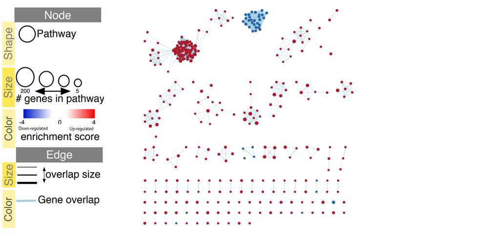

```r
knitr::include_graphics("Figures/EM/initial.png")
```

**Figure 3. Network prior to manual layout.** 354 nodes (circles) represent distinct genesets. Red nodes represent genesets enriched in up-regulated genes, while blue nodes represent genesets enriched in down-regulated genes. 5116 edges (blue lines connecting nodes) represent similarity of genes between two connected genesets.

Next, we formatted the network layout by adjusting the Prefuse Force Directed Layout to be weighted using the geneset similarity coefficient, as recommended in the EnrichmentMap publication Reimand et al. (2019).

Using another Cytoscape app, AutoAnnotate, we clustered and annotated the Enrichment Map with the following parameters Kucera et al. (2016):

- Cluster algorithm: MCL Cluster
- Edge weight column: similarity_coefficient
- Label column: GS_DESCR
- Label algorithm: WordCloud: Adjacent Words (default)
- Max words per label: 3
- Minimum word occurrence: 1
- Adjacent word bonus: 8

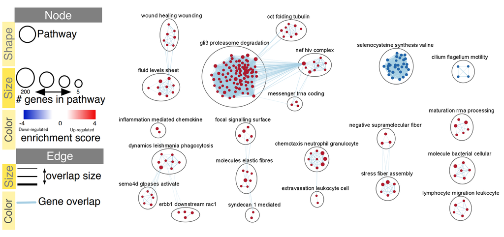

```r
knitr::include_graphics("Figures/EM/cluster.png")
```

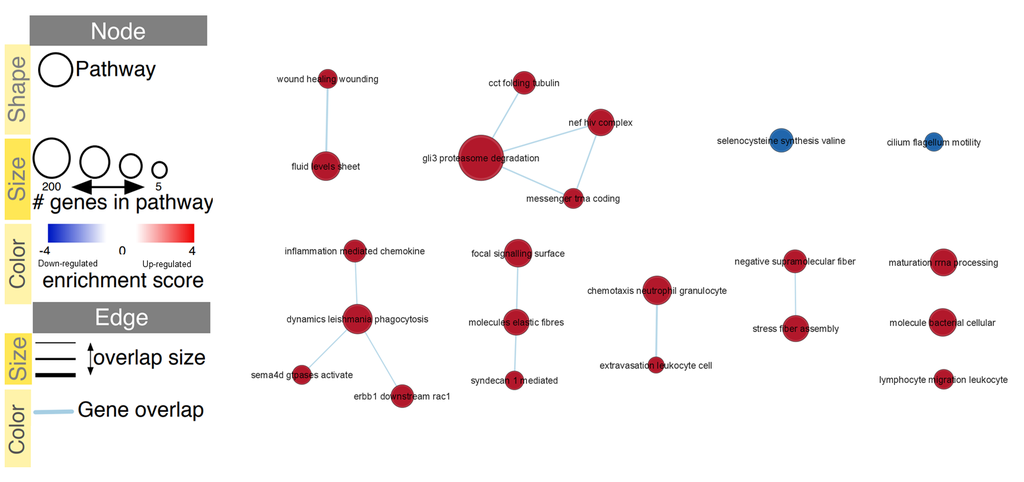

```r
knitr::include_graphics("Figures/EM/summary.png")
```

**Figure 5. Collapsed theme network.** Using the “Create summary network” option, each cluster shown in Fig. 4 has been collapsed into a single node. Individual unconnected nodes have been ommitted.

# Interpretation and detailed view of results

#### Do the enrichment results support conclusions or mechanism discussed in the original paper? How do these results differ from the results you got from Assignment #2 thresholded methods

The enrichment results mostly support the conclusions discussed in the original paper, though the paper’s enrichment results appear to show a greater variety in themes. For up-regulated genes, the paper found enrichment in “viral responses, RNA processing, cytokine responses, cytoskeleton rearrangement, and cell death” (Jacob et al. (2020)). For down-regulated genes, there was enrichment for “ion transport, transmembrane transport, cilium, and cell junction” (Jacob et al. (2020)). The results from GSEA and network analysis appear to be more compreshensive and closer to the paper’s conclusions when compared to our thresholded analysis results from Assignment 2. For example, the thresholded analysis did not find significantly enriched genesets related to cilium, contary to the paper; we found enrichment in terms related to cilium movement from GSEA which remained significant in network analysis.

#### Can you find evidence, i.e. publications, to support some of the results that you see. How does this evidence support your result?

As described in Assignment 2, our results of enrichment in viral response in up-regulated genes and membrane transport in down-regulated genes are supported by the review article “Human Brain Organoids as Models for Central Nervous System Viral Infection” by Depla et al. (2022). The paper reports that multiple studies found evidence of inflammatory response and cytokine signaling in SARS-CoV-2-exposed human brain organoids, as well as impaired secretory function.

The review article “GLI3: a mediator of genetic diseases, development and cancer” by Matissek and Elsawa (2020) also supports the enrichment of “gli3 proteasome degradation” in our network analysis. The paper reports on the role of GLI3 in immune cell development and regulation and tissue development, suggesting this geneset’s connection to the broader themes we have observed in our analyses.

### Additional analysis

To further view a specific pathway in more detail, we selected a WikiPathway geneset, “PATHOGENIC ESCHERICHIA COLI INFECTION%WIKIPATHWAYS_20220510%WP2272%HOMO SAPIENS” which had a size of 33 in our Enrichment Map. We chose this pathway because WikiPathway app Kutmon et al. (2014) allows us to import an interesting visualized pathway, and this particular pathway is related to infection and is thus relevant to the larger enriched theme of inflammatory response.

We imported the pathway-specific data from WikiPathway as well as our ranked gene list from Assignment 2 to visualize the differential expression values of the genes in the pathway.

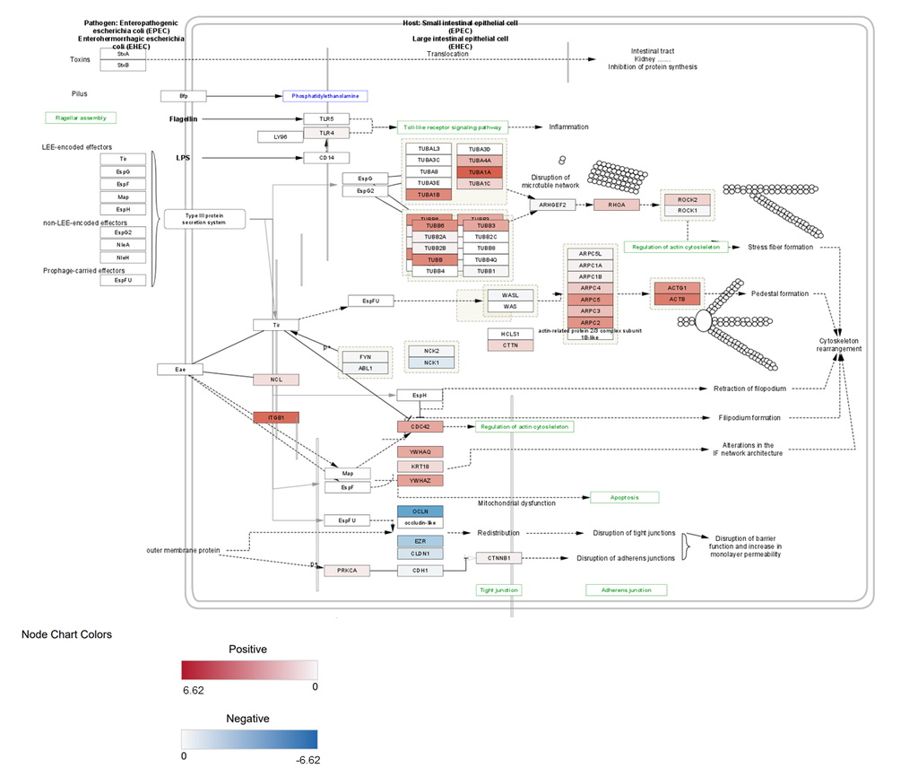

```r
knitr::include_graphics("Figures/EM/pathway.png")
```

**Figure 6. Detailed pathway of WikiPathway “Pathogenic Escherichia coli infection.** The rectangular nodes represent genes in the pathway. Blue represents negative differential expression (down-regulation) while red represents positive differential expression (up-regulation).

In the pathway, up-regulated genes are more prominent than down-regulated genes. Down-regulated genes tend to be closer together in the pathway. Notably, many of the up-regulated genes are in processes leading to cytoskeleton rearrangement (toward the right of the map).

# References

Depla, Josse A., Lance A. Mulder, Renata Vieira de Sá, Morgane Wartel, Adithya Sridhar, Melvin M. Evers, Katja C. Wolthers, and Dasja Pajkrt. 2022. “Human Brain Organoids as Models for Central Nervous System Viral Infection.” *Viruses* 14 (3). https://www.mdpi.com/1999-4915/14/3/634.

“Enrichment Map Genesets.” 2023. *Index of /Em_genesets/March_02_2023/Human/Symbol*. Bader Lab. http://download.baderlab.org/EM_Genesets/March_02_2023/Human/symbol/.

Isserlin, Ruth. 2023a. “BCB420. Cytoscape 101.”

———. 2023b. “BCB420. Lecture 10: Recap and GSEA.”

———. 2023c. “BCB420. Lecture 11: Enrichment Map and Other Cytoscape Apps.”

Jacob, Fadi, Sarshan R Pather, Wei-Kai Huang, Feng Zhang, Samuel Zheng Hao Wong, Haowen Zhou, Beatrice Cubitt, et al. 2020. “Human Pluripotent Stem Cell-Derived Neural Cells and Brain Organoids Reveal SARS-CoV-2 Neurotropism Predominates in Choroid Plexus Epithelium.” *Cell Stem Cell* 27 (6): 937–50.

Kucera, Mike, Ruth Isserlin, Arkady Arkhangorodsky, and Gary D. Bader. 2016. “AutoAnnotate: A Cytoscape App for Summarizing Networks with Semantic Annotations.” *F1000Research* 5 (July): 1717. https://doi.org/10.12688/f1000research.9090.1.

Kutmon, Martina, Samad Lotia, Chris T Evelo, and Alexander R Pico. 2014. “WikiPathways App for Cytoscape: Making Biological Pathways Amenable to Network Analysis and Visualization.” *F1000Research* 3 (September): 152. https://doi.org/10.12688/f1000research.4254.2.

Matissek, Stephan J., and Sherine F. Elsawa. 2020. “GLI3: A Mediator of Genetic Diseases, Development and Cancer.” *Cell Communication and Signaling* 18 (1). https://doi.org/10.1186/s12964-020-00540-x.

Mootha, Vamsi K, Cecilia M Lindgren, Karl-Fredrik Eriksson, Aravind Subramanian, Smita Sihag, Joseph Lehar, Pere Puigserver, et al. 2003. “PGC-1$\upalpha$-Responsive Genes Involved in Oxidative Phosphorylation Are Coordinately Downregulated in Human Diabetes.” *Nature Genetics* 34 (3): 267–73. https://doi.org/10.1038/ng1180.

Reimand, Jüri, Ruth Isserlin, Veronique Voisin, Mike Kucera, Christian Tannus-Lopes, Asha Rostamianfar, Lina Wadi, et al. 2019. “Pathway Enrichment Analysis and Visualization of Omics Data Using g:profiler, GSEA, Cytoscape and EnrichmentMap.” *Nature Protocols* 14 (2): 482–517. https://doi.org/10.1038/s41596-018-0103-9.

Subramanian, Aravind, Pablo Tamayo, Vamsi K. Mootha, Sayan Mukherjee, Benjamin L. Ebert, Michael A. Gillette, Amanda Paulovich, et al. 2005. “Gene Set Enrichment Analysis: A Knowledge-Based Approach for Interpreting Genome-Wide Expression Profiles.” *Proceedings of the National Academy of Sciences* 102 (43): 15545–50. https://doi.org/10.1073/pnas.0506580102.

Xie, Yihui. 2022. *Knitr: A General-Purpose Package for Dynamic Report Generation in r*. https://yihui.org/knitr/.